# Part 2 Homework

```r
R.version.string
```

```
## [1] "R version 3.4.2 (2017-09-28)"
```

```r
Sys.Date()
```

```
## [1] "2017-11-03"
```

```r
#Reading in data from .csv file
fn <- "gardasil.csv"
ga <- read.csv(fn)
#Head of table
head(ga)
```

```
##   Age AgeGroup Race Shots Completed InsuranceType MedAssist Location
## 1  21        1    0     3         1             3         0        1
## 2  21        1    0     3         1             3         0        1
## 3  20        1    0     1         0             1         0        1
## 4  14        0    0     3         1             3         0        1
## 5  17        0    3     2         0             3         0        1
## 6  11        0    1     1         0             0         1        1
##   LocationType PracticeType
## 1            0            1
## 2            0            1
## 3            0            1
## 4            0            0
## 5            0            1
## 6            0            0
```

```r
#End of table
tail(ga)
```

```
##      Age AgeGroup Race Shots Completed InsuranceType MedAssist Location
## 1408  20        1    1     2         0             1         0        3
## 1409  12        0    0     1         0             1         0        3
## 1410  22        1    1     1         0             1         0        3
## 1411  20        1    1     1         0             0         1        3
## 1412  19        1    1     2         0             0         1        3
## 1413  26        1    1     1         0             0         1        3
##      LocationType PracticeType
## 1408            1            2
## 1409            1            2
## 1410            1            2
## 1411            1            2
## 1412            1            2
## 1413            1            2
```

1. Create factors for AgeGroup, Race, Completed, Location.

```r
#AgeGroup Factor
ga$AgeGroup.factor <- factor(ga$AgeGroup,levels = 0:1, labels = c("11-17","18-26"))
#Race Factor
ga$Race.factor <- factor(ga$Race,levels = 0:3, labels = c("white","black","Hispanic","other/unknown"))
#Completed Factor
ga$Completed.factor <- factor(ga$Completed, levels = 0:1, labels = c("no","yes"))
#Location Factor
ga$Location.factor <- factor(ga$Location,levels = 1:4, labels = c("Odenton","White Marsh","Johns Hopkins Outpatient Center","Bayview"))
```

Variable factors

2. Report which variables have missing data and how many of these values are missing.

```r
#No missing data for Age
addmargins(table(ga$Age,useNA="always"))
```

```
##
##   11   12   13   14   15   16   17   18   19   20   21   22   23   24   25
##   30   75   83   85  110  134  128   99  105   92   83   64   80   77   86
##   26 <NA>  Sum
##   82    0 1413
```

```r
#No missing data for AgeGroup
addmargins(table(ga$AgeGroup,useNA="always"))
```

```
##
##    0    1 <NA>  Sum
##  701  712    0 1413
```

```r
#No missing data for Race
addmargins(table(ga$Race,useNA="always"))
```

```
##
##    0    1    2    3 <NA>  Sum
##  732  443   52  186    0 1413
```

```r
#No missing data for Shots
addmargins(table(ga$Shots,useNA="always"))
```

```
##
##    1    2    3 <NA>  Sum
##  440  436  537    0 1413
```

```r
#No missing data for Completed
addmargins(table(ga$Completed,useNA="always"))
```

```
##
##    0    1 <NA>  Sum
##  944  469    0 1413
```

```r
#No missing data for InsuranceType
addmargins(table(ga$InsuranceType,useNA="always"))
```

```
##
##    0    1    2    3 <NA>  Sum
##  275  723   84  331    0 1413
```

```r
#No missing data for MedAssist
addmargins(table(ga$MedAssist,useNA="always"))
```

```
##
##    0    1 <NA>  Sum
## 1138  275    0 1413
```

```r
#No missing data for Location
addmargins(table(ga$Location,useNA="always"))
```

```
##
##    1    2    3    4 <NA>  Sum
##  798  165   89  361    0 1413
```

```r
#No missing data for LocationType
addmargins(table(ga$LocationType,useNA="always"))
```

```
##
##    0    1 <NA>  Sum
##  963  450    0 1413
```

```r
#No missing data for PracticeType
addmargins(table(ga$PracticeType,useNA="always"))
```

```
##
##    0    1    2 <NA>  Sum
##  515  365  533    0 1413
```

No variables had missing data

3. What proportion of patients completed all three shots?

```r
#Proportion of patient's which completed shots
tb <- table(ga$Completed.factor)
prop.table(tb)
```

```
##
##        no       yes
## 0.6680821 0.3319179
```

```r
#Converting proportion to percent
pct <- round(100*prop.table(tb))
pct.sign <- "%"
paste(names(pct), " ", pct,pct.sign,sep = "")
```

```
## [1] "no 67%"  "yes 33%"
```

33% of patients completed all shots

4. Draw a bar chart showing the percentage of patients at each of the four locations.

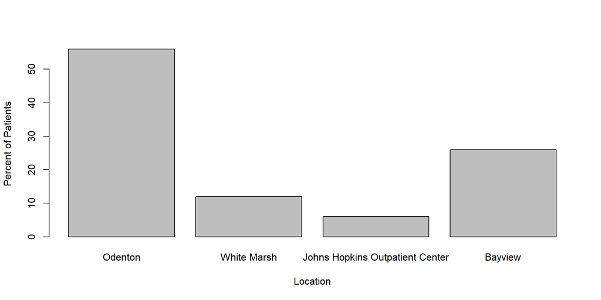

```r
#Bar plot with percentage of patients at the locations (fig.width = 10)
tbloc <- table(ga$Location.factor)
locpct <- round(100*prop.table(tbloc))
barplot(locpct,xlab = "Location", ylab = "Percent of Patients")
```

Barplot with percentage of patient’s at each location

5. Use a crosstabulation to compare Age to AgeGroup, and Location to LocationType. Are the recodings into AgeGroup and LocationType done properly?

```r
#Crosstabulation for Age to AgeGroup
table(ga$Age,ga$AgeGroup.factor)
```

```
##
##      11-17 18-26
##   11    30     0
##   12    75     0
##   13    83     0
##   14    85     0
##   15   110     0
##   16   134     0
##   17   128     0
##   18    56    43
##   19     0   105
##   20     0    92
##   21     0    83
##   22     0    64
##   23     0    80
##   24     0    77
##   25     0    86
##   26     0    82
```

```r
#Crosstabulation for Location to LocationType
ga$Locationtype.factor <- factor(ga$LocationType,levels = 0:1, labels = c("suburban","urban"))
table(ga$Location.factor,ga$Locationtype.factor)
```

```
##
##                                   suburban urban
##   Odenton                              798     0
##   White Marsh                          165     0
##   Johns Hopkins Outpatient Center        0    89
##   Bayview                                0   361
```

6. Create a new variable that combines the race categories into white, and non-white. Calculate the proportion of white patients at each of the four locations.

```r
#Creating new variable
ga$nonwhite <- as.numeric(ga$Race > 0)
#Variable factors
ga$nonwhite.factor <- factor(ga$nonwhite,levels = 0:1, labels = c("white","nonwhite"))
#Calculation proportion at each location
prop <-table(ga$Location.factor,ga$nonwhite.factor)
addmargins(prop)
```

```
##
##                                   white nonwhite  Sum
##   Odenton                           402      396  798
##   White Marsh                       132       33  165
##   Johns Hopkins Outpatient Center    26       63   89
##   Bayview                           172      189  361
##   Sum                               732      681 1413
```

```r
round(100*prop.table(prop,margin = 1),2)
```

```
##
##                                   white nonwhite
##   Odenton                         50.38    49.62
##   White Marsh                     80.00    20.00
##   Johns Hopkins Outpatient Center 29.21    70.79
##   Bayview                         47.65    52.35
```

```r
#Loading epitools library
library(epitools)
#Odds of completing shots by age group
oddsratio(ga$AgeGroup.factor,ga$Completed.factor)$measure
```

```
##          odds ratio with 95% C.I.
## Predictor  estimate     lower   upper
##     11-17 1.0000000        NA      NA
##     18-26 0.8329207 0.6670009 1.03966
```

```r
#Odds of completing shots by race
oddsratio(ga$Race.factor,ga$Completed.factor)$measure
```

```
##                odds ratio with 95% C.I.
## Predictor        estimate     lower     upper
##   white         1.0000000        NA        NA
##   black         0.5021170 0.3840888 0.6529575
##   Hispanic      0.7879574 0.4221671 1.4166645
##   other/unknown 0.9097329 0.6484316 1.2681132
```

```r
#Odds of completing shots by location
oddsratio(ga$Location.factor,ga$Completed.factor)$measure
```

```
##                                  odds ratio with 95% C.I.
## Predictor                          estimate     lower     upper
##   Odenton                         1.0000000        NA        NA
##   White Marsh                     1.7888960 1.2738129 2.5114358
##   Johns Hopkins Outpatient Center 0.5195762 0.2981058 0.8645118
##   Bayview                         0.6799450 0.5142094 0.8939921
```

```r
#Risk of completing shots by age group
riskratio(ga$AgeGroup.factor,ga$Completed.factor)$measure
```

```
##          risk ratio with 95% C.I.
## Predictor  estimate     lower   upper
##     11-17 1.0000000        NA      NA
##     18-26 0.8848997 0.7629666 1.02632
```

```r
#Risk of completing shots by race
riskratio(ga$Race.factor,ga$Completed.factor)$measure
```

```
##                risk ratio with 95% C.I.
## Predictor        estimate     lower    upper
##   white         1.0000000        NA       NA
##   black         0.6196388 0.5120320 0.749860
##   Hispanic      0.8546703 0.5724981 1.275919
##   other/unknown 0.9417051 0.7614297 1.164662
```

```r
#Risk of completing shots by location
riskratio(ga$Location.factor,ga$Completed.factor)$measure
```

```
##                                  risk ratio with 95% C.I.
## Predictor                          estimate     lower     upper
##   Odenton                         1.0000000        NA        NA
##   White Marsh                     1.4069421 1.1703719 1.6913310
##   Johns Hopkins Outpatient Center 0.6194893 0.4110868 0.9335425
##   Bayview                         0.7636364 0.6268663 0.9302470
```

8. Place all the key results into a Word document, PowerPoint presentation, as a PDF file or as an HTML file. Turn it in by email. Use the subject line: “Introduction to R, (your name), Part 2 Homework”